# OS FATORES QUE INFLUENCIAM NA NOTA DO ENEM ALÉM DOS ESTUDOS - Análise do ENEM 2019 - Projeto Final Semantix

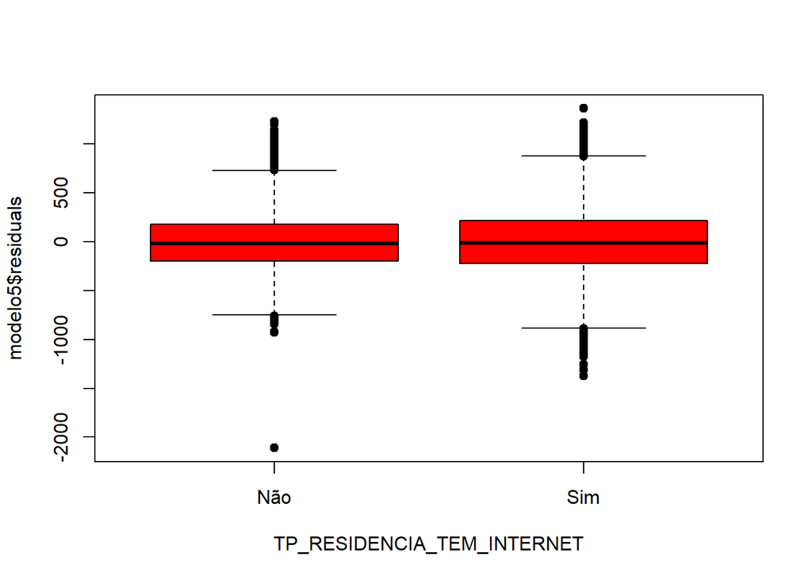

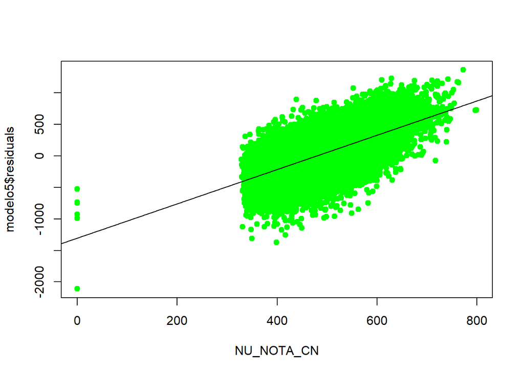

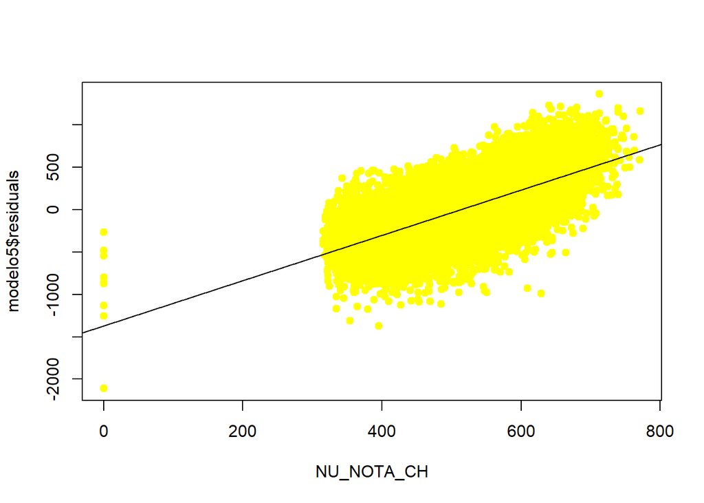

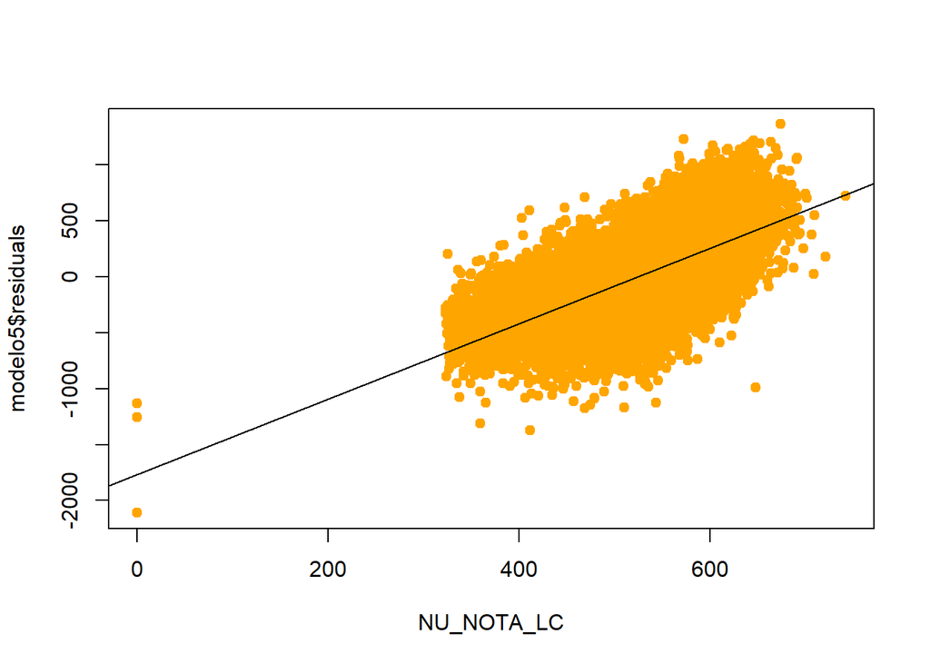

[3 more figures not shown]

### Verificação da normalidade

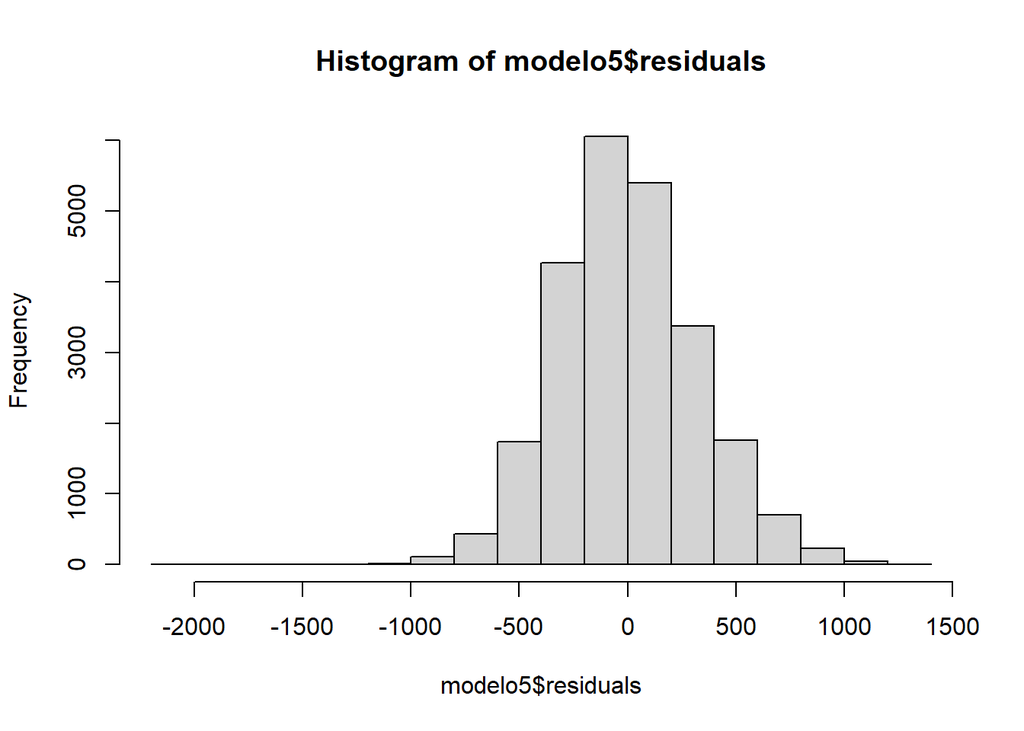

```
##
##  Anderson-Darling normality test
##
## data:  modelo5$residuals
## A = 29.847, p-value < 2.2e-16
```

### Verificação da homocedasticidade

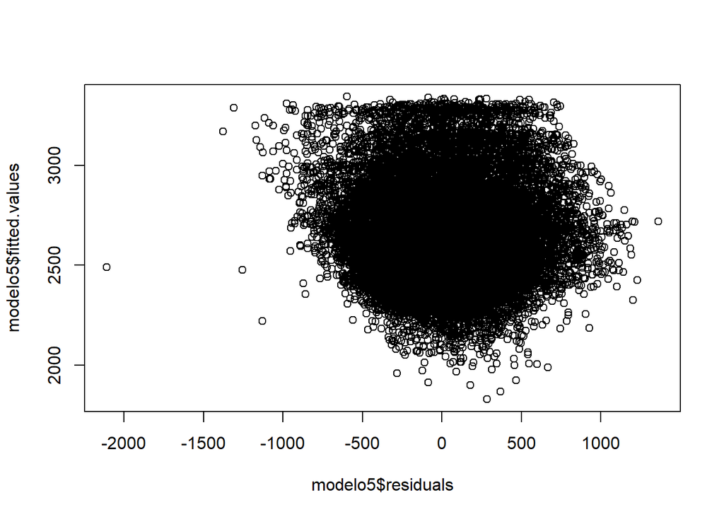

```
##
##  studentized Breusch-Pagan test
##
## data:  modelo5
## BP = 641.23, df = 2, p-value < 2.2e-16
```

### Medida de ajuste do modelo de regressão linear múltipla

```
## [1] 0.3372749
```

## Ajuste do modelo random florest

### Execução do método para detecção de variáveis importantes

|  | attr_importance |
| --- | --- |
| NU_IDADE | 107.598766 |
| TP_SEXO | 39.288871 |
| TP_ESTADO_CIVIL | 37.679012 |
| TP_COR_RACA | 38.145827 |
| TP_NACIONALIDADE | 19.121325 |
| TP_ANO_CONCLUIU | 91.487214 |
| TP_ENSINO | -5.870237 |
| TP_REGIAO_RESIDENCIA | 45.944964 |
| TP_GRAU_INSTRUCAO_MULHER | 56.172427 |
| TP_RENDA_MENSAL | 106.500193 |

[output cut: 2 more lines]

### Ajuste do modelo random florest

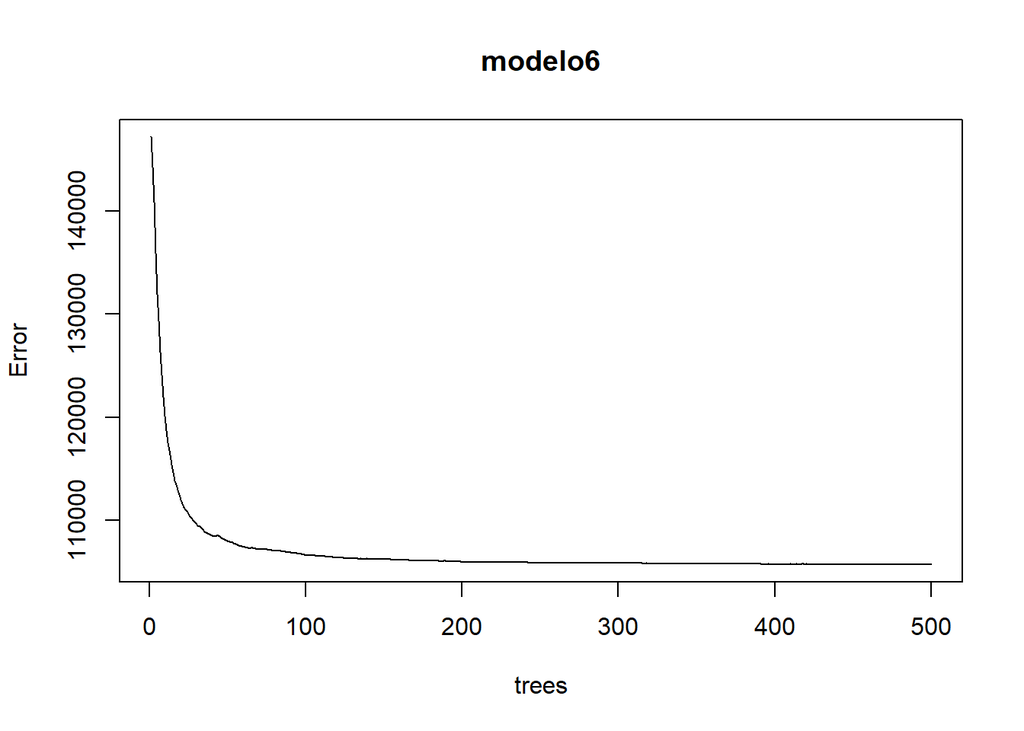

```
##                 Length Class  Mode
## call                5  -none- call
## type                1  -none- character
## predicted       24109  -none- numeric
## mse               500  -none- numeric
## rsq               500  -none- numeric
## oob.times       24109  -none- numeric
## importance         22  -none- numeric
## importanceSD       11  -none- numeric
## localImportance     0  -none- NULL
## proximity           0  -none- NULL
## ntree               1  -none- numeric
## mtry                1  -none- numeric
## forest             11  -none- list
## coefs               0  -none- NULL
## y               24109  -none- numeric
## test                0  -none- NULL
## inbag               0  -none- NULL
## terms               3  terms  call
```

### Medida de ajuste do modelo random florest

```
## [1] 0.3286958
```

# 5 - Resultados alcançados

• Pela análise exploratória dos dados precebemos que:

- conforme destacado no artigo citado no Capítulo 1, renda familiar e nível de escolaridade da mãe continuam impactando na nota final do inscrito;
- presença maior de escritos do sexo feminino;
- predominância de inscritos da raça Parda, Branca e Preta, respectivamente;
- a amostragem não obteve uma representatividade no tocante ao Tipo de Escola, Localização da Escola e Situação do Funcionamento da Escola. Essas variáveis foram excluídas do modelo;
- a presença de *outliers* pode estar relacionada com as variáveis com observações nulas. Optou-se em não realizar nenhum tratamento nos dados para esse caso;
- a nota da prova de Redação é aparentemente simétrica e sugere uma distribuição normal. As demais notas apresentam distribuição com assimétria à esquerda. Quanto à curtose, a distribuição é Leptocúrtica (caudas longas ou pesadas).

• Sobre o ajuste do modelo de regressão linear múltipla:

- o modelo ajustou melhor com as variáveis significativas “idade”, “sexo”, “estado civil”, “nacionalidade”, “ano concluiu ensino médio”, “tipo ensino”, “região da residência”, “grau de instrução da mulher”, “renda mensal”, “tipo residência tem computador” e “tipo residência tem internet”;
- o modelo foi ajustado com o coeficiente de determinação R2 ajustado igual a 0,3366;
- a interpretação para o modelo é: fixando os valores de “sexo”, “estado civil”, “nacionalidade”, “ano concluiu ensino médio”, “tipo ensino”, “região da residência”, “grau de instrução da mulher”, “renda mensal”, “tipo residência tem computador” e “tipo residência tem internet”, aumentando 1 unidade na “idade”, diminui em média -11,4163 na “nota geral da prova”;
- o modelo acima apresenta os coeficientes e valores estimados, no qual os resultados demonstram coerência estatística entre o modelo escolhido e a distribuição empírica dos dados;
- o modelo não indica suposição de linearidade;
- os resíduos não são normais, conforme testes realizados acima;
- o modelo indica problema com a suposição de homoscedasticidade nos dados;
- apesar de tudo, considera-se um modelo razoável para início de análise de desempenho dos inscritos no ENEM.

# 6 - Conclusão

A análise contribuiu para criar um modelo inicial que pudesse dizer quais variáveis relacionadas a infraestrutura e socioeconômica importantes que influênciam ou não na nota final do ENEM e, de certa forma, poderá predizer a nota final do inscrito.

São fatores passíveis de direcionamento para o INEP (órgão público que controla o ENEM) utilizar para melhorar as políticas de bolsa de estudo para a entrada nas Universidades públicas e privadas.

O modelo poderá ser inserido em um contexto maior, no qual possibilitará entender melhor a política de cotas para inscritos, como na modalidade **Lei de Cotas (Lei Federal 12.711)**, que são as vagas das instituições federais para candidatos que estudaram todo o ensino médio em escolas públicas ou concluíram através da Educação de Jovens e Adultos (EJA) ou Enem.

# 7 - Referências Bibliograficas

- SOUZA, Marcelle. **Renda e escolaridade da mãe puxam notas de candidatos no ENEM, aponta estudo**. Disponível em: https://www.cnnbrasil.com.br/nacional/renda-e-escolaridade-da-mae-puxam-notas-de-candidatos-no-enem-aponta-estudo/. Acesso em dezembro de 2021.
- BOLFARINE, Heleno; BUSSAB, Wilton O. **Elementos de Amostragem**. São Paulo: Blucher, 1ª ed., 2005.
- LEVIN, Jack. **Estatística Aplicada a Ciências Humanas**. São Paulo: Harbra Ltda, 2ª ed., 1987.
- TODD, S. **Data Science and Innovation**, http://stevetodd.typepad.com/my_weblog/2012/10/data-science-and-innovation.html. Acesso em dezembro de 2021.